# DecisionTree

## 实验介绍

### 1.实验内容

本实验包括:

- 学习并实现决策树算法----以ID3算法为例
- 基于决策树算法预测隐形眼镜类型

### 2.实验目标

通过本实验掌握决策树算法的基本原理。

### 3.实验知识点

- 香农熵
- 信息增益
- 决策树算法基本原理

### 4.实验环境

- python 3.6.5
- numpy 1.13.3
- matplotlib 2.2.3

### 实验准备

点击屏幕右上方的下载实验数据模块，选择下载decision_tree_glass.tgz到指定目录下，然后再依次选择点击上方的File->Open->Upload,上传刚才下载的数据集压缩包，再使用如下命令解压：

```python
!tar -zxvf decision_tree_glass.tgz
```

```
decision_tree_glass/
decision_tree_glass/lenses.txt
decision_tree_glass/classifierStorage.txt
```

## 实验步骤：【海洋动物分类】- 概述

下表数据包含5个海洋动物，特征包括：不浮出水面是否可以生存，以及是否有脚蹼。我们将这些动物分成两类：鱼类和非鱼类。本实验要求基于决策树算法（ID3）实现对下表数据的分类。

| id | 不浮出水面是否可以生存 | 是否有脚蹼 | 属于鱼类 |
| --- | --- | --- | --- |
| 1 | 是 | 是 | 是 |
| 2 | 是 | 是 | 是 |
| 3 | 是 | 否 | 否 |
| 4 | 否 | 是 | 否 |
| 5 | 否 | 是 | 否 |

```python
import math
import matplotlib.pyplot as plt
```

## 实验步骤：【海洋动物分类】- 创建数据集

基于上述表格，创建数据集。

```python
def createDataSet():
    """
    函数说明：创建数据集
    returns:
        dataSet - 数据集
        labels - 分类属性
    """
    dataSet = [[1, 1, 'yes'],
               [1, 1, 'yes'],
               [1, 0, 'no'],
               [0, 1, 'no'],
               [0, 1, 'no']]
    labels = ['no surfacing','flippers']
    return dataSet, labels
```

## 实验步骤：【海洋动物分类】- 计算香农熵

```python
# 计算给定数据集的香农熵
def calcShannonEnt(dataSet):
    """
    函数说明:计算给定数据集的香农熵
    parameters:
        dataSet - 数据集
    returns:
        shannonEnt - 香农熵
    """
    numEntries = len(dataSet)  # 数据集的样本数量
    labelCounts = {}  # 创建一个数据字典，它的键是数据集最后一列的数据，集样本的类别；它的值是该分类中的样本数量
    # 计算每种类别下的样本数量，并将其放在字典中对应的键下
    for featureVec in dataSet:
        label = featureVec[-1]  # 取样本中的最后一个值
        if label not in labelCounts.keys():
            labelCounts[label] = 1
        else:
            labelCounts[label] += 1
    # 计算数据集的熵
    shannonEnt = 0.0
    for key in labelCounts.keys():
        val = float(labelCounts[key]) / numEntries
        shannonEnt -= val * math.log(val, 2)
    return shannonEnt
```

## 实验步骤：【海洋动物分类】- 特征选择(基于信息增益划分数据集)

信息增益是相对于特征而言的，信息增益越大，特征对最终的分类结果影响也就越大，我们就应该选择对最终分类结果影响最大的那个特征作为我们的分类特征。

splitDataSet函数是用来选择各个特征的子集的。chooseBestFeatureToSplit函数是选择选择最优特征的函数。

```python
# 按照给定的特征划分数据集
def splitDataSet(dataSet, axis, value):
    """
    函数说明: 按照给定特征划分数据集
    parameters:
        dataSet - 待划分的数据集
        axis - 划分数据集的特征 (第axis个特征)
        value - 特征值
    returns:
        retDataSet - 划分后的数据集
    """
    reDataSet = []
    for featureVector in dataSet:
        if featureVector[axis] == value:
            reduceFeature = featureVector[:axis]
            reduceFeature.extend(featureVector[axis + 1:])
            reDataSet.append(reduceFeature)
    return reDataSet


# 选择最好的数据集划分方式
def chooseBestFeatureToSplit(dataSet):
    """
    函数说明: 选择最优特征
    parameters:
        dataSet - 数据集
    returns:
        bestFeature - 信息增益最大的(最优)特征的索引值
    """
    numOfFeature = len(dataSet[0]) - 1
    baseShannon = calcShannonEnt(dataSet)  #
    bestShannon = 0.0
    bestFeature = -1
    for i in range(numOfFeature):
        featureList = [featureVector[i] for featureVector in dataSet]  # 用列表推导式将第i个特征的值提取出来
        featureSet = set(featureList)  # 利用集合的互异性找出特征的不同取值
        newShannon = 0.0
        for value in featureSet:
            subDataSet = splitDataSet(dataSet, i, value)  # 按照不同的特征划分数据集
            # 求新划分的数据集的香农熵
            prob = float(len(subDataSet)) / float(len(dataSet))
            newShannon += prob * calcShannonEnt(subDataSet)
        shannon = baseShannon - newShannon
        if shannon > bestShannon:
            bestShannon = shannon
            bestFeature = i
    return bestFeature
```

## 实验步骤：【海洋动物分类】- 构建决策树

决策树构建算法流程：得到原始数据集，基于最好的属性值划分数据集。第一次划分之后，数据将被向下传递到树分支的下一个节点，在这个节点上，再次划分数据。采用递归的原则处理数据集。

递归结束条件：程序遍历完所有划分数据集的属性，或者每个分支下的所有实例都具有相同的分类。

```python
# 该函数使用分类名称的列表，然后创建键值为classList中唯一值的数据字典，字典对象存储了classList中每个类标签出现的频率，
# 最后利用operator操作键值排序字典，并返回出现次数最多的分类名称。
def majorityCnt(classList):
    classCount = {}
    for vote in classList:
        if vote not in classCount.keys():
            classCount[vote] = 0
        classCount[vote] += 1
    sortedClassCount = sorted(classCount.iteritems(),key=operator.itemgetter(1), reverse=True)
    return sortedClassCount[0][0]


#递归构建决策树
def createTree(dataSet,labels):
    """
    函数说明:创建决策树
    Parameters:
        dataSet - 训练数据集
        labels - 分类属性标签
    Returns:
        myTree - 决策树
    """
    classList = [example[-1] for example in dataSet]
    # 递归函数第一个停止的条件：所有类标签完全相同，直接返回该类标签
    if classList.count(classList[0]) == len(classList):
        return classList[0]
    # 递归函数的第二个停止条件：使用完所有特征，仍不能将数据集划分成仅包含唯一类别的分组。使用多数表决法决定叶子节点的分类
    if len(dataSet[0]) == 1:
        return majorityCnt(classList)
    # 开始创建决策树
    bestFeature = chooseBestFeatureToSplit(dataSet)  #选择划分数据集最好的特征的索引
    bestFeatureLabel = labels[bestFeature]           #根据特征的索引提取索引的名称
    decisionTree = {bestFeatureLabel:{}}             #将此特征作为树的根节点
    del labels[bestFeature]                        #将已放进树中的特征从特征标签中删除
    featrueValues = [example[bestFeature]for example in dataSet]  #提取所有样本关于这个特征的取值
    uniqueVals = set(featrueValues)                               #应用集合的互异性，提取这个特征的不同取值
    for value in uniqueVals:                       #根据特征的不同取值，创建这个特征所对应结点的分支
        subLabels = labels[:]
        decisionTree[bestFeatureLabel][value]=createTree(splitDataSet(dataSet,bestFeature,value),subLabels)
    return decisionTree
```

## 实验步骤：【海洋动物分类】- 使用决策树进行分类

```python
def classify(inputTree, featLabels, testVec):
    """
    函数说明:使用决策树分类
    Parameters:
        inputTree - 已经生成的决策树
        featLabels - 存储选择的最优特征标签
        testVec - 测试数据列表，顺序对应最优特征标签
    Returns:
        classLabel - 分类结果
    """
    firstStr = list(inputTree.keys())[0]
    secondDict = inputTree[firstStr]
    featIndex = featLabels.index(firstStr)
    for key in secondDict.keys():
        if testVec[featIndex] == key:
            if type(secondDict[key]).__name__ == 'dict':
                classLabel = classify(secondDict[key], featLabels, testVec)
            else:
                classLabel = secondDict[key]
    return classLabel
```

```python
if __name__ == '__main__':
    testVec1 = [1,0]
    testVec2 = [1,1]
    dataSet, labels = createDataSet()
    decisiontree = createTree(dataSet, labels)
    dataSet, labels = createDataSet()
    print(classify(decisiontree, labels, testVec1))
    print(classify(decisiontree, labels, testVec2))
    # 使用决策树对testVec1和testVec2分类
```

```
no
yes
```

## 【预测隐形眼镜类型】

## 实验步骤：【预测隐形眼镜类型】- 概述

本实验要求基于决策树算法，帮助人们判断需要佩戴的镜片类型。

### 数据介绍

隐形眼镜数据集是非常著名的数据集，它包含很多换着眼部状态的观察条件以及医生推荐的隐形眼镜类型。隐形眼镜类型包括硬材质(hard)、软材质(soft)以及不适合佩戴隐形眼镜(no lenses)。

数据集一共有24组数据，数据的Labels依次是age、prescript、astigmatic、tearRate、class，也就是第一列是年龄，第二列是症状，第三列是是否散光，第四列是眼泪数量，第五列是最终的分类标签。

## 实验步骤：【预测隐形眼镜类型】- 创建决策树

编写代码，基于隐形眼镜数据集构造决策树，并输出。

```python
def loadData(path):
    fr = open(path)
    lenses = [line.strip().split('\t') for line in  fr.readlines()]
    lensesLabels = ['age','prescript','astigmatic','tearRate']
    return lenses, lensesLabels
```

```python
def getNumLeafs(myTree):
    """
        函数说明：
            得到树的叶子结点个数
            绘制一棵完整的树需要一些技巧。我们虽然有x、y坐标，但是如何放置所有的树节点却是个问题。
            我们必须知道有多少个叶节点，以便可以正确确定x轴的长度.
        Parameters：
            myTree：决策树
        Return:
            numLeafs:叶子结点个数
    """
    numLeafs = 0        # 结点数目初始化
    temp_keys = list(myTree.keys()) # mytree: {'no surfacing': {0: 'no', 1: {'flippers': {0: 'no', 1: 'yes'}}}}
    firstStr = temp_keys[0]     # 这里我们取到决策树的第一个key值
    secondDict = myTree[firstStr]   # 由于树的嵌套字典格式 我们通过第一个key得到了其value部分的另一个字典
    for key in secondDict.keys():   # 取出第二字典的key 0和1
        if type(secondDict[key]).__name__ == 'dict':
            # 判断是否相应key的value是不是字典 是字典就不是叶子结点
            # 继续调用本函数拆分该字典直到不是字典 即为叶子结点 进行记录
            numLeafs += getNumLeafs(secondDict[key])
        else:   # 不是字典直接记录为叶子结点
            numLeafs += 1
    return numLeafs


def getTreeDepth(myTree):
    """
        函数说明：
            得到树的深度
            我们还需要确定树的深度，以便于确定y轴的高度
        Parameters：
            myTree：决策树
        Return:
            maxDepth：树高
    """
    maxDepth = 0
    # firstStr = myTree.keys()[0]
    firstStr = next(iter(myTree))   # 这里有第二种方法可以取到到第一个key值
    secondDict = myTree[firstStr]
    for key in secondDict.keys():
        if type(secondDict[key]).__name__ == 'dict':
            # 与记录叶子结点数目类似 一个字典算是一层的代表（因为字典必有分支）
            thisDepth = 1 + getTreeDepth(secondDict[key])
        else:
            # 是叶子结点也给他记作一层 但是要注意 当同一层不单单只是叶子结点 有下层分支时
            # 会将本来有两层的计数重置为一层 为了避免这一错误 我们有了下面的if判断
            thisDepth = 1
        if thisDepth > maxDepth:
            maxDepth = thisDepth
    return maxDepth


decisionNode = dict(boxstyle='sawtooth',fc='0.8')       #决策节点；设置文本框的类型和文本框背景灰度，范围为0-1，0为黑，1为白，不设置默认为蓝色
leafNode = dict(boxstyle='round4',fc='1')               #设置叶子节点文本框的属性
arrow_args = dict(arrowstyle='<-')


def plotNode(nodeTxt, centerPt, parentPt, nodeType):
    """
        函数说明：
            使用文本注解绘制树节点
        parameters：
            nodeTxt：注释文段
            centerPt：文本中心坐标
            parentPt：箭头尾部坐标
            nodeType：注释文本类型
        Return：
            无返回 执行annotate（）画布
    """
    createPlot.ax1.annotate(nodeTxt, xy=parentPt,  xycoords='axes fraction',
             xytext=centerPt, textcoords='axes fraction',
             va="center", ha="center", bbox=nodeType, arrowprops=arrow_args )


def plotMidText(cntrPt, parentPt, txtString):
    """
        函数说明：
            在父子结点间填充文本信息
        Parameters：
            cntrPt，parentPt：用于计算标注位置（我们取父子连线的中点作为标注位置）
            txtString:标注内容
        Return:
            None
    """
    xMid = (parentPt[0]-cntrPt[0])/2.0 + cntrPt[0]
    yMid = (parentPt[1]-cntrPt[1])/2.0 + cntrPt[1]
    # (parentPt[0]+cntrPt[0])/2.0 考虑：
    # 这次案例中 发现两个公式的树画出来的是相互对称的
    createPlot.ax1.text(xMid, yMid, txtString, va="center", ha="center", rotation=30)



def plotTree(myTree, parentPt, nodeTxt):
    """
        函数说明：
            绘制决策树---筹备
        Parameters：
            myTree:决策树
            parentPt：父节点位置（在上节中是箭头尾部 箭头头部是子节点）父节点----->子节点
            nodeTxt：标注信息
        Special:
            numLeafs:当前结点的叶子节点数（是在变的）
            tatalW:树的总叶子数
        Return:
            None
    """
    numLeafs = getNumLeafs(myTree)  # 得到叶子结点计算树的宽度
    depth = getTreeDepth(myTree)    # 得到树深度
    firstStr = list(myTree.keys())[0]     # 得到根结点（父节点）注释内容
    cntrPt = (plotTree.xOff + (1.0 + float(numLeafs))/2.0/plotTree.totalW, plotTree.yOff)# 根节点位置
    plotMidText(cntrPt, parentPt, nodeTxt)  # 画连线标注
    plotNode(firstStr, cntrPt, parentPt, decisionNode)  # 画结点 画线
    secondDict = myTree[firstStr]   # 解析下一个字典（根节点）/叶子
    plotTree.yOff = plotTree.yOff - 1.0/plotTree.totalD     # 计算下一个结点的y
    for key in secondDict.keys():
        if type(secondDict[key]).__name__ == 'dict':    # 子树
            plotTree(secondDict[key], cntrPt, str(key))
        else:   # 叶子节点
            plotTree.xOff = plotTree.xOff + 1.0/plotTree.totalW
            plotNode(secondDict[key], (plotTree.xOff, plotTree.yOff), cntrPt, leafNode)
            plotMidText((plotTree.xOff, plotTree.yOff), cntrPt, str(key))
    plotTree.yOff = plotTree.yOff + 1.0/plotTree.totalD
    # 递归完后需要回退到上层，绘制当前树根节点的其他分支节点。



def createPlot(inTree):
    """
        函数说明：
           绘制决策树---执行
        Parameters：
            inTree:决策树
        Return:
            None 展示画布
    """
    fig = plt.figure(1, facecolor='white')
    fig.clf()
    axprops = dict(xticks=[], yticks=[])    # 定义x，y轴为空 为后面不显示轴作准备
    createPlot.ax1 = plt.subplot(111, frameon=False, **axprops)    # 传入刚才定义参数 构造子图
    # createPlot.ax1 = plt.subplot(111, frameon=False) # 有轴的
    plotTree.totalW = float(getNumLeafs(inTree))
    # tatalW:树的宽度初始化 = 叶子节点
    plotTree.totalD = float(getTreeDepth(inTree))
    # tatalD:树的深度 = 树高
    plotTree.xOff = -0.5/plotTree.totalW    # 为开始x位置为第一个表格左边的半个表格距离位置
    plotTree.yOff = 1.0     # y位置1
    # 使用两个全局变量plotTree.xOff、plotTree.yOff追踪已经绘制的节点位置
    # 这部分代码直接去看很难理解 之后会有注解
    plotTree(inTree, (0.5, 1.0), '')    # 调用函数开始绘图 一开始标注为空 因为第一个就是根结点
    plt.show()
```

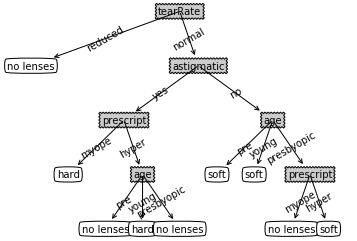

```python
if __name__ == '__main__':
    path = 'decision_tree_glass/lenses.txt'
    lenses, lenseLabels = loadData(path)
    lensesTree = createTree(lenses,lenseLabels)
    createPlot(lensesTree)
```